# Sydney Airbnb Pricing — Analysis

COMM3501 Module 1 portfolio project

Colin Priest

02 June 2026

# 1 Introduction

This notebook fits a **log-linear regression of nightly price** on listing features, geography, and review signals for Sydney Airbnb listings, using only Module 1 methods (EDA, multiple regression, dummy variables, interactions, log transforms, and residual diagnostics).

**A note on the data vintage.** Inside Airbnb’s most recent Sydney release (2025-09-12) ships the `price` column completely blank in both `listings.csv.gz` and `calendar.csv.gz` — there is no nightly price to model. I therefore use the most recent Sydney scrape that still publishes prices, **2023-06-06**. This is documented in the README and is the kind of data-quality check worth doing before any modelling.

# 2 Load and first look

```r
# read_csv (readr / tidyverse) handles the gzip and quoted multi-line fields.
raw <- read_csv("listings.csv.gz", show_col_types = FALSE) |>
  clean_names()

dim(raw)            # rows, columns
```

```
[1] 23451    75
```

```r
# A one-line summary of every column.
skim(raw %>% select(price, accommodates, bedrooms, bathrooms_text,
                     room_type, neighbourhood_cleansed,
                     review_scores_rating, number_of_reviews,
                     host_is_superhost, latitude, longitude))
```

Data summary

| Name | %>%(…) |
| --- | --- |
| Number of rows | 23451 |
| Number of columns | 11 |
| _______________________ |  |
| Column type frequency: |  |
| character | 4 |
| logical | 1 |
| numeric | 6 |
| ________________________ |  |
| Group variables | None |

**Variable type: character**

| skim_variable | n_missing | complete_rate | min | max | empty | n_unique | whitespace |
| --- | --- | --- | --- | --- | --- | --- | --- |
| price | 0 | 1 | 6 | 10 | 0 | 1256 | 0 |
| bathrooms_text | 15 | 1 | 6 | 17 | 0 | 34 | 0 |
| room_type | 0 | 1 | 10 | 15 | 0 | 4 | 0 |
| neighbourhood_cleansed | 0 | 1 | 4 | 16 | 0 | 38 | 0 |

**Variable type: logical**

| skim_variable | n_missing | complete_rate | mean | count |
| --- | --- | --- | --- | --- |
| host_is_superhost | 6475 | 0.72 | 0.17 | FAL: 14082, TRU: 2894 |

**Variable type: numeric**

| skim_variable | n_missing | complete_rate | mean | sd | p0 | p25 | p50 | p75 | p100 | hist |
| --- | --- | --- | --- | --- | --- | --- | --- | --- | --- | --- |
| accommodates | 0 | 1.00 | 3.62 | 2.32 | 1.00 | 2.00 | 3.00 | 4.00 | 16.00 | ▇▂▁▁▁ |
| bedrooms | 7500 | 0.68 | 2.11 | 1.17 | 1.00 | 1.00 | 2.00 | 3.00 | 13.00 | ▇▁▁▁▁ |
| review_scores_rating | 5897 | 0.75 | 4.53 | 0.93 | 0.00 | 4.50 | 4.81 | 5.00 | 5.00 | ▁▁▁▁▇ |
| number_of_reviews | 0 | 1.00 | 21.59 | 50.04 | 0.00 | 0.00 | 3.00 | 18.00 | 942.00 | ▇▁▁▁▁ |
| latitude | 0 | 1.00 | -33.86 | 0.08 | -34.10 | -33.90 | -33.88 | -33.82 | -33.38 | ▁▇▂▁▁ |
| longitude | 0 | 1.00 | 151.19 | 0.10 | 150.63 | 151.16 | 151.21 | 151.26 | 151.34 | ▁▁▁▃▇ |

The `price` column arrives as a string (`"$1,250.00"`) and `bathrooms_text` as free text (`"2 baths"`, `"1 shared bath"`, `"Half-bath"`). Both are cleaned below. `neighbourhood_cleansed` holds the 38 Sydney LGAs, which we will bundle into a handful of interpretable regions.

# 3 Exploratory data analysis

## 3.1 Price — the case for a log transform

```r
# Strip "$" and "," then coerce to numeric (readr::parse_number does both).
raw <- raw %>% mutate(price_num = parse_number(price))

raw %>%
  summarise(n = sum(!is.na(price_num)),
            min = min(price_num, na.rm = TRUE),
            median = median(price_num, na.rm = TRUE),
            mean = mean(price_num, na.rm = TRUE),
            p99 = quantile(price_num, 0.99, na.rm = TRUE),
            max = max(price_num, na.rm = TRUE))
```

| n | min | median | mean | p99 | max |
| --- | --- | --- | --- | --- | --- |
| 23451 | 16 | 170 | 289.4775 | 2000 | 32133 |

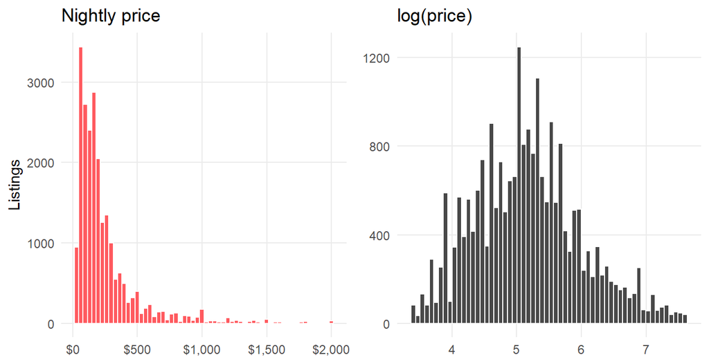

```r
# Side-by-side: raw price (heavily right-skewed) vs log price (near-normal).
plot_df <- raw %>%
  filter(!is.na(price_num), price_num >= 30, price_num <= 2000)

p1 <- ggplot(plot_df, aes(price_num)) +
  geom_histogram(bins = 60, fill = ACCENT, colour = "white") +
  scale_x_continuous(labels = dollar_format()) +
  labs(title = "Nightly price", x = NULL, y = "Listings")

p2 <- ggplot(plot_df, aes(log(price_num))) +
  geom_histogram(bins = 60, fill = NEUTRAL, colour = "white") +
  labs(title = "log(price)", x = NULL, y = NULL)

cowplot::plot_grid(p1, p2, nrow = 1)
```

*Raw price is sharply right-skewed; the log transform is approximately bell-shaped, which justifies modelling `log(price)` rather than `price` (lecture slide 138).*

## 3.2 Other numeric columns

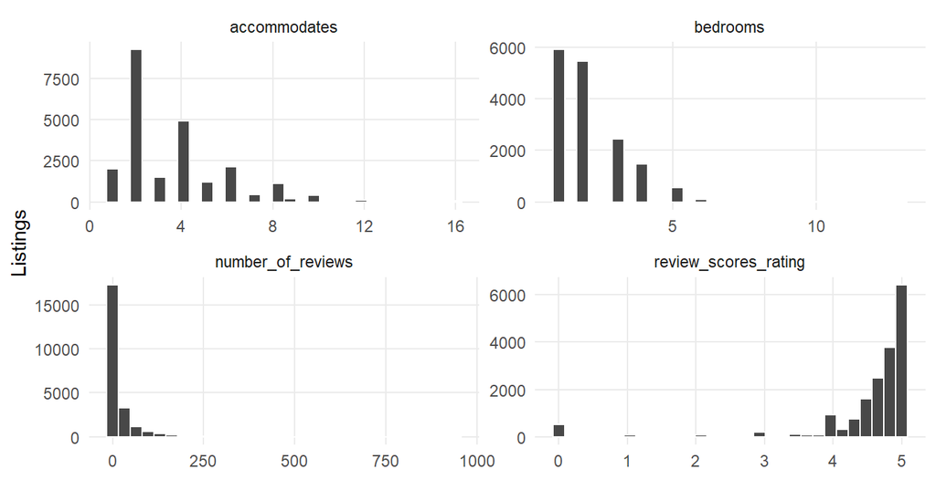

```r
raw %>%
  transmute(accommodates,
            bedrooms,
            number_of_reviews,
            review_scores_rating) %>%
  pivot_longer(everything()) %>%
  filter(!is.na(value)) %>%
  ggplot(aes(value)) +
  geom_histogram(bins = 30, fill = NEUTRAL, colour = "white") +
  facet_wrap(~name, scales = "free") +
  labs(x = NULL, y = "Listings")
```

*`accommodates` and `bedrooms` are right-skewed count variables; `number_of_reviews` has a long tail; `review_scores_rating` clusters near the top of the 0–5 scale (most rated listings sit above 4.5).*

## 3.3 Categorical columns

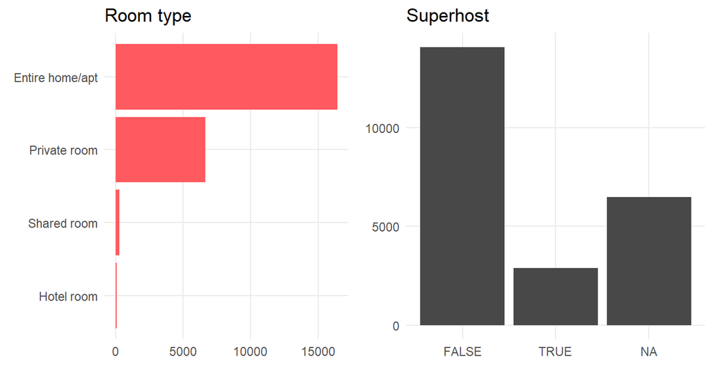

```r
b1 <- raw %>% count(room_type, sort = TRUE) %>%
  ggplot(aes(fct_reorder(room_type, n), n)) +
  geom_col(fill = ACCENT) + coord_flip() +
  labs(title = "Room type", x = NULL, y = NULL)

b2 <- raw %>% count(host_is_superhost) %>%
  ggplot(aes(factor(host_is_superhost), n)) +
  geom_col(fill = NEUTRAL) +
  labs(title = "Superhost", x = NULL, y = NULL)

cowplot::plot_grid(b1, b2, nrow = 1)
```

## 3.4 Missing values

```r
raw %>%
  summarise(across(c(price_num, bedrooms, accommodates, bathrooms_text,
                     review_scores_rating, number_of_reviews),
                   ~ sum(is.na(.)))) %>%
  pivot_longer(everything(), names_to = "column", values_to = "n_missing") %>%
  arrange(desc(n_missing))
```

| column | n_missing |
| --- | --- |
| bedrooms | 7500 |
| review_scores_rating | 5897 |
| bathrooms_text | 15 |
| price_num | 0 |
| accommodates | 0 |
| number_of_reviews | 0 |

*`review_scores_rating` is missing exactly for listings with no reviews — a structural, not random, gap. We retain those listings (dropping them would discard a sizeable share of the market) and handle the missing score explicitly in feature engineering.*

## 3.5 Geographic sanity check

```r
# 1,000 random listings, coloured by room type, to confirm coordinates are sane.
pal_rt <- colorFactor("Set1", raw$room_type)
raw %>%
  slice_sample(n = 1000) %>%
  leaflet() %>%
  addProviderTiles("CartoDB.Positron") %>%
  setView(lng = 151.2093, lat = -33.8688, zoom = 10) %>%
  addCircleMarkers(~longitude, ~latitude, radius = 3, stroke = FALSE,
                   fillOpacity = 0.6, color = ~pal_rt(room_type)) %>%
  addLegend("bottomright", pal = pal_rt, values = ~room_type, title = "Room type")
```

[interactive chart not shown]

*Listings fall where we expect them — dense around the CBD, the eastern beaches, and the lower north shore — confirming the coordinates are usable.*

# 4 Feature engineering and cleaning

```r
# Great-circle distance (km) from each listing to the Sydney CBD.
haversine_km <- function(lat, lon, lat0 = -33.8688, lon0 = 151.2093) {
  R <- 6371                       # Earth radius, km
  to_rad <- function(d) d * pi / 180
  dlat <- to_rad(lat - lat0)
  dlon <- to_rad(lon - lon0)
  a <- sin(dlat / 2)^2 +
       cos(to_rad(lat0)) * cos(to_rad(lat)) * sin(dlon / 2)^2
  2 * R * asin(pmin(1, sqrt(a)))
}
```

```r
# Parse bathrooms_text into a numeric count + a shared-bathroom flag.
parse_baths <- function(x) {
  x_l <- str_to_lower(x)
  num <- parse_number(x_l)                     # "1.5 baths" -> 1.5
  # "Half-bath" / "Private half-bath" / "Shared half-bath" -> 0.5
  ifelse(str_detect(x_l, "half"), 0.5, num)
}

clean <- raw %>%
  mutate(
    price          = price_num,
    bathrooms      = parse_baths(bathrooms_text),
    shared_bath    = str_detect(str_to_lower(bathrooms_text), "shared"),
    log_price      = log(price),
    dist_to_cbd_km = haversine_km(latitude, longitude),
    is_entire_home = room_type == "Entire home/apt",
    has_reviews    = number_of_reviews > 0,
    host_is_superhost = host_is_superhost %in% c(TRUE, "t")
  )
```

```r
# Bundle the 38 LGAs into 10 interpretable regions using local Sydney knowledge.
clean <- clean %>%
  mutate(neighbourhood_group = case_when(
    neighbourhood_cleansed %in% c("Sydney") ~ "City",
    neighbourhood_cleansed %in% c("Waverley", "Randwick", "Woollahra") ~ "Eastern Suburbs",
    neighbourhood_cleansed %in% c("Marrickville", "Leichhardt", "Canada Bay",
      "Ashfield", "Burwood", "Strathfield", "Canterbury", "Inner West") ~ "Inner West",
    neighbourhood_cleansed %in% c("North Sydney", "Mosman", "Willoughby",
      "Lane Cove", "Hunters Hill") ~ "Lower North Shore",
    neighbourhood_cleansed %in% c("Ku-Ring-Gai", "Hornsby", "Ryde") ~ "Upper North Shore",
    neighbourhood_cleansed %in% c("Manly", "Warringah", "Pittwater",
      "Northern Beaches") ~ "Northern Beaches",
    neighbourhood_cleansed %in% c("Botany Bay", "Rockdale", "Hurstville",
      "City Of Kogarah", "Bayside", "Georges River") ~ "Inner South",
    neighbourhood_cleansed %in% c("Sutherland Shire") ~ "Sutherland",
    neighbourhood_cleansed %in% c("The Hills Shire") ~ "Hills",
    neighbourhood_cleansed %in% c("Parramatta", "Auburn", "Holroyd", "Cumberland",
      "Blacktown", "Penrith", "Liverpool", "Fairfield", "Bankstown",
      "Canterbury-Bankstown", "Campbelltown", "Camden", "Blue Mountains",
      "Hawkesbury", "Wollondilly") ~ "Western Sydney",
    TRUE ~ "Other Sydney"
  ))

# Safety check: confirm nothing fell through to "Other Sydney".
clean %>% count(neighbourhood_group, sort = TRUE)
```

| neighbourhood_group | n |
| --- | --- |
| Eastern Suburbs | 5698 |
| City | 5162 |
| Northern Beaches | 3489 |
| Inner West | 2416 |
| Western Sydney | 1883 |
| Lower North Shore | 1801 |
| Inner South | 1121 |
| Upper North Shore | 1103 |
| Sutherland | 489 |
| Hills | 289 |

```r
n_before <- nrow(clean)

model_df <- clean %>%
  filter(!is.na(price), price >= 30, price <= 2000,  # drop implausible / luxury outliers
         !is.na(bedrooms), !is.na(accommodates),     # core size predictors required
         !is.na(bathrooms),
         !is.na(dist_to_cbd_km)) %>%
  mutate(
    # Structural missingness: impute the median rating for no-review listings,
    # already flagged by has_reviews (documented choice, see write-up).
    review_scores_rating = if_else(is.na(review_scores_rating),
                                   median(review_scores_rating, na.rm = TRUE),
                                   review_scores_rating),
    # Reference categories chosen for interpretability.
    room_type = fct_relevel(factor(room_type), "Entire home/apt"),
    neighbourhood_group = fct_relevel(factor(neighbourhood_group), "City")
  )

tibble(stage = c("raw", "after filters"),
       rows  = c(n_before, nrow(model_df)),
       dropped = c(NA, n_before - nrow(model_df)))
```

| stage | rows | dropped |
| --- | --- | --- |
| raw | 23451 | NA |
| after filters | 15717 | 7734 |

```r
saveRDS(model_df, "airbnb_clean.rds")
```

# 5 Models

```r
m1 <- lm(log_price ~ accommodates + bedrooms + bathrooms, data = model_df)

m2 <- lm(log_price ~ accommodates + bedrooms + bathrooms +
           room_type + neighbourhood_group + dist_to_cbd_km +
           review_scores_rating + host_is_superhost, data = model_df)

m3 <- lm(log_price ~ accommodates + bedrooms + bathrooms +
           room_type + neighbourhood_group + dist_to_cbd_km +
           review_scores_rating + host_is_superhost +
           room_type:neighbourhood_group, data = model_df)
```

## 5.1 Model comparison

```r
model_compare <- bind_rows(
  glance(m1) %>% mutate(model = "M1: size only"),
  glance(m2) %>% mutate(model = "M2: full additive"),
  glance(m3) %>% mutate(model = "M3: + interaction")
) %>%
  transmute(model,
            adj_r_squared = round(adj.r.squared, 3),
            resid_se = round(sigma, 3),
            n_params = nobs - df.residual,   # number of coefficients (incl. intercept)
            AIC = round(AIC, 0))

model_compare
```

| model | adj_r_squared | resid_se | n_params | AIC |
| --- | --- | --- | --- | --- |
| M1: size only | 0.441 | 0.526 | 4 | 24423 |
| M2: full additive | 0.526 | 0.485 | 18 | 21845 |
| M3: + interaction | 0.528 | 0.483 | 34 | 21787 |

*Adjusted R² rises sharply from M1 (size only) to M2 (adding room type, geography, and reviews), but then barely moves from M2 to M3 — the interaction block buys only about 0.2 percentage points. Because all three share the same response (`log_price`), the slide-67 rule applies, but here the gain from the interaction is negligible against the ~16 extra parameters it costs. **I therefore prefer the additive Model 2** on parsimony grounds, and use it for interpretation, diagnostics, and the dashboard. (Model 3 is still examined below to confirm the interaction is not doing meaningful work.)*

## 5.2 Coefficient interpretation (back-transformed)

```r
# Percentage effect of a one-unit change = (exp(b) - 1) * 100%.
tidy(m2) %>%
  filter(term %in% c("bathrooms", "bedrooms", "accommodates",
                     "room_typePrivate room", "host_is_superhostTRUE",
                     "review_scores_rating", "dist_to_cbd_km")) %>%
  mutate(pct_effect = round((exp(estimate) - 1) * 100, 1)) %>%
  select(term, estimate, pct_effect, p.value)
```

| term | estimate | pct_effect | p.value |
| --- | --- | --- | --- |
| accommodates | 0.066157933 | 6.8 | 4.978762e-80 |
| bedrooms | 0.166072141 | 18.1 | 3.847267e-106 |
| bathrooms | 0.209113180 | 23.3 | 2.362874e-161 |
| room_typePrivate room | -0.228677414 | -20.4 | 1.243533e-23 |
| dist_to_cbd_km | 0.001182391 | 0.1 | 1.172006e-01 |
| review_scores_rating | 0.062887847 | 6.5 | 1.049044e-27 |
| host_is_superhostTRUE | 0.132628686 | 14.2 | 1.528267e-35 |

Reading these from the preferred additive model (M2), in plain business terms:

- **Each extra bathroom** adds about **+23%** to the nightly price, and **each extra bedroom** about **+18%** — size is the dominant driver.
- **Private room** vs entire home: roughly **−20%** cheaper for an otherwise identical listing. Note this market is ~96% entire homes (only 487 private rooms survive filtering), so this estimate, while strongly significant, rests on a small slice of the data.
- **Superhost** status carries a **+14%** premium — small but very significant.
- **Distance to the CBD is *not* significant** (p ≈ 0.12). This is not a mistake: it is the slide-40 “partial effect” lesson in action. Once we know a listing’s *region*, its raw kilometres-from-CBD adds nothing — Bondi is expensive because it is in the Eastern Suburbs, not because of its distance. The neighbourhood dummies have already absorbed the geography.

## 5.3 Joint significance of the interaction

```r
anova(m2, m3)   # F-test: does the room_type x neighbourhood interaction help?
```

|  | Res.Df | RSS | Df | Sum of Sq | F | Pr(>F) |
| --- | --- | --- | --- | --- | --- | --- |
| 1 | 15699 | 3685.266 | NA | NA | NA | NA |
| 2 | 15683 | 3664.259 | 16 | 21.00718 | 5.619411 | 2.84864e-12 |

*The F-test is significant (p ≈ 3 × 10⁻¹²), so the interaction is statistically detectable — at n ≈ 15,700 even tiny effects clear significance. But it lifts adjusted R² by only ~0.2 points, which is **practically** negligible. With the market ~96% entire homes, there is little room-type variation for an interaction to exploit. This is a clean example of statistical vs practical significance, and it confirms the choice of the simpler M2.*

# 6 Diagnostics

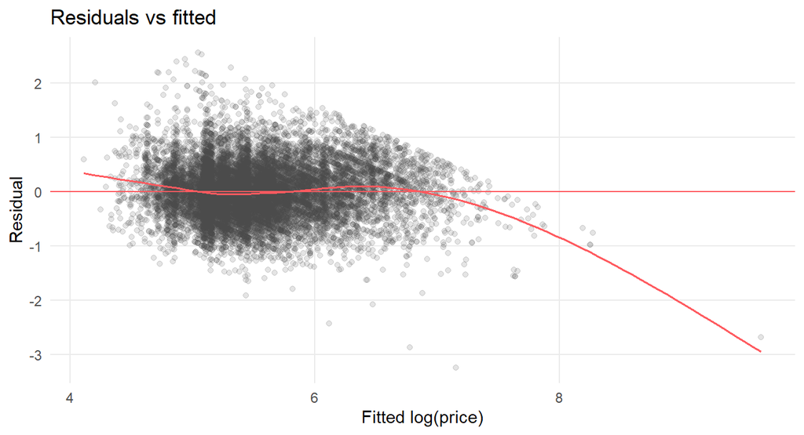

```r
# Diagnostics on the preferred model, M2.
diag_df <- tibble(fitted = fitted(m2), resid = residuals(m2))

ggplot(diag_df, aes(fitted, resid)) +
  geom_point(alpha = 0.15, colour = NEUTRAL) +
  geom_hline(yintercept = 0, colour = ACCENT) +
  geom_smooth(se = FALSE, colour = ACCENT, linewidth = 0.6) +
  labs(title = "Residuals vs fitted", x = "Fitted log(price)", y = "Residual")
```

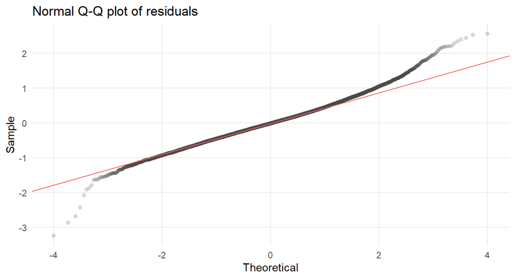

```r
ggplot(diag_df, aes(sample = resid)) +
  stat_qq(alpha = 0.2, colour = NEUTRAL) + stat_qq_line(colour = ACCENT) +
  labs(title = "Normal Q-Q plot of residuals", x = "Theoretical", y = "Sample")
```

```r
# VIF is computed on the additive model M2: with interaction terms present,
# VIFs are mechanically inflated and not interpretable, so we assess
# multicollinearity on M2 (the standard practice).
vif(m2)
```

```
                         GVIF Df GVIF^(1/(2*Df))
accommodates         4.332773  1        2.081531
bedrooms             4.938144  1        2.222194
bathrooms            2.262477  1        1.504153
room_type            1.049046  2        1.012042
neighbourhood_group  3.271601  9        1.068065
dist_to_cbd_km       3.188855  1        1.785737
review_scores_rating 1.026211  1        1.013021
host_is_superhost    1.045319  1        1.022408
```

*Among the size variables, `accommodates`, `bedrooms`, and `bathrooms` are correlated, but VIFs stay in the low single digits — moderate, not damaging (slide 102). We retain all three; none exceeds the conventional threshold of 5 that would prompt dropping a variable.*

```r
# Shapiro-Wilk caps at n = 5,000, so test a random sample of residuals.
shapiro.test(sample(residuals(m2), 5000))
```

```
    Shapiro-Wilk normality test

data:  sample(residuals(m2), 5000)
W = 0.99376, p-value = 5.948e-14
```

*Shapiro-Wilk rejects normality — expected at this sample size and consistent with the Q-Q plot. The honest summary of the diagnostics: **heteroskedasticity is present, residuals are heavy-tailed and non-normal, and there is moderate (not severe) multicollinearity among the size variables.** None of these invalidates the large-sample coefficient inference that drives the conclusions.*

# 7 Predictions and residuals for the dashboard

```r
# Predictions come from the preferred model, M2.
scored <- model_df %>%
  mutate(
    predicted_log   = predict(m2, model_df),
    predicted_price = exp(predicted_log),
    residual        = log_price - predicted_log,           # < 0 => below model = potentially underpriced
    pct_vs_model    = (price / predicted_price - 1) * 100  # actual vs predicted, %
  )

saveRDS(scored, "airbnb_clean.rds")   # overwrite with predictions attached
saveRDS(m2, "model.rds")              # preferred model for the dashboard
```

```r
top_under <- scored %>% arrange(residual) %>% slice_head(n = 10) %>%
  select(neighbourhood_group, room_type, price, predicted_price, pct_vs_model)
top_over  <- scored %>% arrange(desc(residual)) %>% slice_head(n = 10) %>%
  select(neighbourhood_group, room_type, price, predicted_price, pct_vs_model)

top_under
```

| neighbourhood_group | room_type | price | predicted_price | pct_vs_model |
| --- | --- | --- | --- | --- |
| Lower North Shore | Entire home/apt | 50 | 1280.0354 | -96.09386 |
| Lower North Shore | Entire home/apt | 50 | 878.1834 | -94.30643 |
| Upper North Shore | Entire home/apt | 1061 | 15484.5427 | -93.14801 |
| Northern Beaches | Entire home/apt | 40 | 452.3355 | -91.15701 |
| City | Entire home/apt | 81 | 646.8092 | -87.47699 |
| Eastern Suburbs | Entire home/apt | 34 | 229.6439 | -85.19447 |
| Eastern Suburbs | Entire home/apt | 150 | 969.1666 | -84.52278 |
| Northern Beaches | Hotel room | 56 | 336.3533 | -83.35084 |
| Eastern Suburbs | Entire home/apt | 45 | 233.6008 | -80.73637 |
| City | Entire home/apt | 121 | 618.8679 | -80.44817 |

```r
top_over
```

| neighbourhood_group | room_type | price | predicted_price | pct_vs_model |
| --- | --- | --- | --- | --- |
| Lower North Shore | Entire home/apt | 2000 | 154.9519 | 1190.7233 |
| Lower North Shore | Entire home/apt | 2000 | 160.0726 | 1149.4328 |
| City | Entire home/apt | 1600 | 139.0762 | 1050.4486 |
| Upper North Shore | Entire home/apt | 1425 | 130.2041 | 994.4352 |
| Upper North Shore | Entire home/apt | 1466 | 140.6509 | 942.2973 |
| City | Entire home/apt | 1999 | 203.2701 | 883.4206 |
| City | Entire home/apt | 1400 | 151.6580 | 823.1294 |
| Inner West | Entire home/apt | 1100 | 122.2142 | 800.0590 |
| Inner South | Entire home/apt | 1000 | 111.4117 | 797.5720 |
| City | Entire home/apt | 1400 | 157.1498 | 790.8699 |

*Negative residuals (top table) are listings priced **below** what their features predict — candidates for a price rise. Positive residuals are priced **above** prediction; this does **not** prove the host is overcharging, only that the model is missing a feature (a harbour view, a recent renovation, a bridge sightline). We frame it that way deliberately.*

# 8 Key numbers (exported for the dashboard and README)

```r
# "Region premium" = mean residual from a FEATURES-ONLY model (no geography),
# i.e. how much each region sits above/below what listing features alone predict.
# (Average residuals from M2 are ~0 within each region, because M2 already
# contains the neighbourhood dummies — so we need the features-only model here.)
m_features <- lm(log_price ~ accommodates + bedrooms + bathrooms + room_type +
                   review_scores_rating + host_is_superhost, data = scored)

region_premium <- scored %>%
  mutate(res_feat = residuals(m_features)) %>%
  group_by(neighbourhood_group) %>%
  summarise(n = n(), premium_pct = round((exp(mean(res_feat)) - 1) * 100, 1)) %>%
  arrange(desc(premium_pct))

co  <- coef(m2)
pct <- function(b) round((exp(b) - 1) * 100, 1)

key_numbers <- list(
  n_listings  = nrow(scored),
  scrape_date = "2023-06-06",
  adj_r2      = round(summary(m2)$adj.r.squared * 100, 1),  # preferred model (M2)
  adj_r2_m1   = round(summary(m1)$adj.r.squared * 100, 1),
  adj_r2_m3   = round(summary(m3)$adj.r.squared * 100, 1),
  bathroom_pct     = pct(co[["bathrooms"]]),
  bedroom_pct      = pct(co[["bedrooms"]]),
  private_room_pct = pct(co[["room_typePrivate room"]]),
  superhost_pct    = pct(co[["host_is_superhostTRUE"]]),
  dist_km_pct      = pct(co[["dist_to_cbd_km"]]),
  dist_km_p        = round(summary(m2)$coefficients["dist_to_cbd_km", "Pr(>|t|)"], 3),
  region_premium   = region_premium,
  top_over_region  = as.character(region_premium$neighbourhood_group[1]),
  top_over_pct     = region_premium$premium_pct[1],
  top_under_region = as.character(tail(region_premium$neighbourhood_group, 1)),
  top_under_pct    = tail(region_premium$premium_pct, 1)
)
saveRDS(key_numbers, "key_numbers.rds")
key_numbers
```

```
$n_listings
[1] 15717

$scrape_date
[1] "2023-06-06"

$adj_r2
[1] 52.6

$adj_r2_m1
[1] 44.1

$adj_r2_m3
[1] 52.8

$bathroom_pct
[1] 23.3

$bedroom_pct
[1] 18.1

$private_room_pct
[1] -20.4

$superhost_pct
[1] 14.2

$dist_km_pct
[1] 0.1

$dist_km_p
[1] 0.117

$region_premium
# A tibble: 10 × 3
   neighbourhood_group     n premium_pct
   <fct>               <int>       <dbl>
 1 Northern Beaches     2914        22.5
 2 Eastern Suburbs      3867         8.7
 3 City                 3392         5.5
 4 Lower North Shore    1347         3.3
 5 Sutherland            403        -4
 6 Inner West           1371       -18.9
 7 Upper North Shore     684       -22.8
 8 Hills                 173       -26.7
 9 Inner South           500       -28.5
10 Western Sydney       1066       -33.6

$top_over_region
[1] "Northern Beaches"

$top_over_pct
[1] 22.5

$top_under_region
[1] "Western Sydney"

$top_under_pct
[1] -33.6
```

```
2023-06-06
```

```
Northern Beaches
```

```
Western Sydney
```

The dashboard (`dashboard.Rmd`) reads `airbnb_clean.rds`, `model.rds`, and `key_numbers.rds` to build the map, tables, and effect plots, and the README’s executive summary quotes these figures directly.